# 5. Endothelial cluster analysis

# 9 Introduction of bootstrap

We use the “boot” R package to perform bootstrap analysis. The R package boot allows a user to easily generate bootstrap samples (10000) of virtually any statistic that they can calculate in R. We perform bootstrap analysis for the mixture of cell types from six samples.

Four outputs will be generated including:

- Variance of bootstrap resamples (needed by bootstrap using bca bootstrap method). Smaller variance indicates better consistency among the resamples.
- 95% Confidence Intervals (CIs) used to test the statistical confidence of the bootstrap results. 95% probability can be ensured that the estimated statistic falls within the CI. CIs are calculated by normal approximation (norm), basic bootstrap (basic), bootstrap percentile (perc, and bootstrap percentile (bca).
- Histogram including a dotted vertical line, which indicates the location of the original statistic.
- Quantile-quantile (q-q) plot, a graphical technique for determining if two data sets come from populations with a common distribution. The x-axis represents the standard normal distribution, while the y-axis denotes the distribution of the resamples.

# 10 Cell subtype percentages of Control 00d

## 10.1 Bootstrap of the percentage of Homeostatic cells

Summary of the bootstrap resamples:

|  | R | original | bootBias | bootSE | bootMed |
| --- | --- | --- | --- | --- | --- |
| 1 | 10000 | 0.8536585 | -0.0002757955 | 0.03930201 | 0.8541667 |

The variance of the percentage of homeostatic cells in the bootstrap resamples is 0.0015446.

The confidence interval of the percentage of homeostatic cells in the bootstrap resamples.

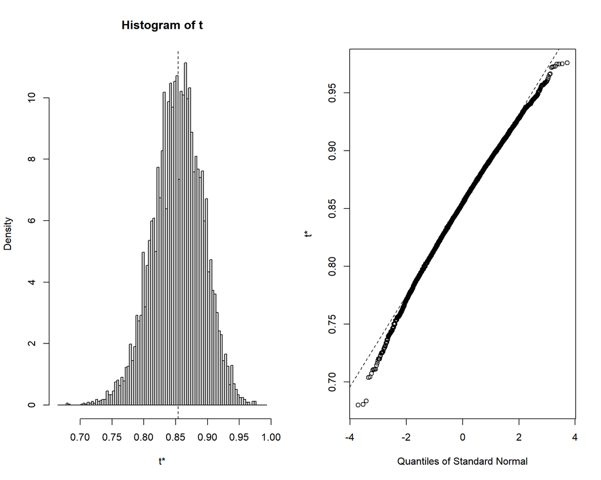

```
## BOOTSTRAP CONFIDENCE INTERVAL CALCULATIONS
## Based on 10000 bootstrap replicates
##
## CALL :
## boot.ci(boot.out = bootcorr, type = c("norm", "basic", "perc",
##     "bca"))
##
## Intervals :
## Level      Normal              Basic
## 95%   ( 0.7769,  0.9310 )   ( 0.7808,  0.9346 )
##
## Level     Percentile            BCa
## 95%   ( 0.7727,  0.9265 )   ( 0.7611,  0.9200 )
## Calculations and Intervals on Original Scale
```

## 10.2 Bootstrap of the percentage of Differentiating cells

Summary of the bootstrap resamples:

|  | R | original | bootBias | bootSE | bootMed |
| --- | --- | --- | --- | --- | --- |
| 1 | 10000 | 0.08536585 | 0.0003909791 | 0.03128149 | 0.08433735 |

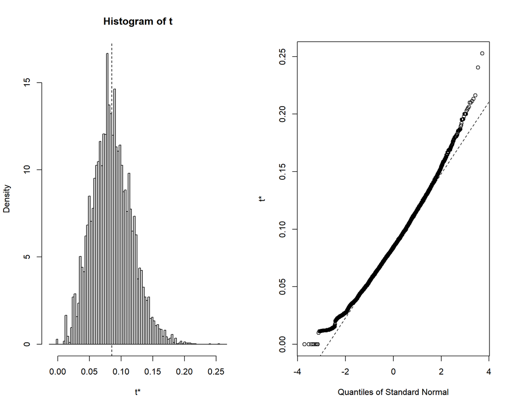

```
## BOOTSTRAP CONFIDENCE INTERVAL CALCULATIONS
## Based on 10000 bootstrap replicates
##
## CALL :
## boot.ci(boot.out = bootcorr, type = c("norm", "basic", "perc",
##     "bca"))
##
## Intervals :
## Level      Normal              Basic
## 95%   ( 0.0237,  0.1463 )   ( 0.0192,  0.1426 )
##
## Level     Percentile            BCa
## 95%   ( 0.0282,  0.1515 )   ( 0.0357,  0.1647 )
## Calculations and Intervals on Original Scale
```

## 10.3 Bootstrap of the percentage of Perivascular macrophages cells

Summary of the bootstrap resamples:

|  | R | original | bootBias | bootSE | bootMed |
| --- | --- | --- | --- | --- | --- |
| 1 | 10000 | 0.04878049 | -1.688891e-05 | 0.02388456 | 0.04705882 |

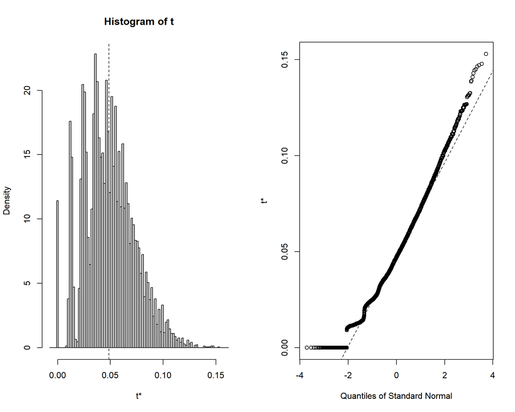

```
## BOOTSTRAP CONFIDENCE INTERVAL CALCULATIONS
## Based on 10000 bootstrap replicates
##
## CALL :
## boot.ci(boot.out = bootcorr, type = c("norm", "basic", "perc",
##     "bca"))
##
## Intervals :
## Level      Normal              Basic
## 95%   ( 0.0020,  0.0956 )   (-0.0037,  0.0867 )
##
## Level     Percentile            BCa
## 95%   ( 0.0109,  0.1013 )   ( 0.0127,  0.1154 )
## Calculations and Intervals on Original Scale
```